# R: nuts and bolts

Day 3

## Where do things live?

### **Working Directory**

- Directory where R first looks for files.
  - If you run `read.csv("mydata.csv")` then `mydata.csv` should be in your working directory
- Check current location (your location will be different):

```r
> getwd()
[1] "C:/Users/mgelman/Dropbox/econ122-f22/docs"
```

- **R Markdown:** When you `knit` a .Rmd file, the working directory for the compilation of the document is always the **directory where the .Rmd file is located!**
  - This may be different from the location of your current Rstudio session.

## Where do things live?

### **Workspace**

- This is the “environment” where R objects live.
  - See the **Environment** tab in Rstudio
- Check the contents of my (or your) environment

```r
> ls()
character(0)
```

(If it says `character(0)` then your workspace is empty!)

- **R Markdown:** When you `knit` a .Rmd file, a completely **new and separate working space** is created.
  - **why do you think this is the case?**
  - R chunk may throw an error if you reference an object loaded in your workspace but not via R chunk

## Where do things live?

### **Rstudio Projects**

- Projects set your working directory to the folder it lives in
  - easy way to set your working directory
  - can save and reload your workspace (environment)
- Projects can be connected to GitHub using Rstudio’s GUI
- **Highly recommend:** create a project for this class in the folder you are using to store class work.
  - see [Hadley’s page on projects](http://r4ds.had.co.nz/workflow-projects.html)

## Objects in R

- Anything created or imported into R is called an **object**
  - vectors, data frames, matrices, lists, functions, lm, …
- We usually store objects in the workspace using the assignment **operator** `<-`

```r
> x <- c(8,2,1,3)
> ls()
[1] "x"
```

- The `=` operator also does assignment, but it is mainly used for argument specification inside a function.

```r
> y <- rnorm(3, mean=10, sd=2)
> ls()
[1] "x" "y"
```

- Please don’t use `=` for variable assignment!!!

## Data types

### Determines computer storage of info

- Important data types
  - Logical: TRUE and FALSE are the only values
  - Numeric class: Integer and double
    - default is double
  - Character: string (““) of text

```r
> typeof(x)  # type of storage mode
[1] "double"
> typeof("abc")
[1] "character"
> x == 1
[1] FALSE FALSE  TRUE FALSE
> typeof(x == 1)
[1] "logical"
```

## Vectors

### Shape of an object

- R uses two types of vectors to store info
  - **atomic vectors**: all entries have the same data type
  - **lists**: entries can contain other objects that can differ in data type
- All vectors have a length

```r
> x
[1] 8 2 1 3
> length(x)
[1] 4
> x.list<- list(x,1,"a")
> length(x.list)
[1] 3
```

## Atomic Vectors: Matrices

- You can add **attributes**, such as **dimension**, to vectors
- A **matrix** is a 2-dimensional vector containing entries of the same type

```r
> x
[1] 8 2 1 3
> x.mat <- matrix(x, nrow=2, byrow=TRUE)
> x.mat
     [,1] [,2]
[1,]    8    2
[2,]    1    3
> class(x.mat)
[1] "matrix" "array"
> str(x.mat)
 num [1:2, 1:2] 8 1 2 3
```

- Note: `str` is a handy way of dispalying the structure of objects

## Atomic Vectors: Matrices

- or you can bind vectors of the same length to create columns or rows:

```r
> x.mat2 <- cbind(x,2*x)
> x.mat2
     x
[1,] 8 16
[2,] 2  4
[3,] 1  2
[4,] 3  6
```

## Lists: Data frames

- A **data frame** is a list of atomic vectors of the same length, but not necessarily the same data type
- the `loans` data frame has columns that are `integer` and `factor` types

```r
> loans <- read.csv("https://raw.githubusercontent.com/mgelman/data/master/CreditData.csv",stringsAsFactors=TRUE)
> class(loans)
[1] "data.frame"
> typeof(loans)
[1] "list"
> str(loans)
'data.frame':   1000 obs. of  21 variables:
 $ Status.of.existing.checking.account                     : Factor w/ 4 levels "... < 0 DM","... >= 200 DM / salary assignments for at least 1 year",..: 1 3 4 1 1 4 4 3 4 3 ...
 $ Duration.in.month                                       : int  6 48 12 42 24 36 24 36 12 30 ...
 $ Credit.history                                          : Factor w/ 5 levels "all credits at this bank paid back duly",..: 2 4 2 4 3 4 4 4 4 2 ...
 $ Purpose                                                 : Factor w/ 10 levels "business","car (new)",..: 8 8 5 6 2 5 6 3 8 2 ...
 $ Credit.amount                                           : int  1169 5951 2096 7882 4870 9055 2835 6948 3059 5234 ...
 $ Savings.account.bonds                                   : Factor w/ 5 levels ".. >= 1000 DM",..: 5 2 2 2 2 5 4 2 1 2 ...
 $ Present.employment.since                                : Factor w/ 5 levels ".. >= 7 years",..: 1 3 4 4 3 3 1 3 4 5 ...
 $ Installment.rate.in.percentage.of.disposable.income     : int  4 2 2 2 3 2 3 2 2 4 ...
 $ Personal.status.and.sex                                 : Factor w/ 4 levels "female : divorced/separated/married",..: 4 1 4 4 4 4 4 4 2 3 ...
 $ Other.debtors.guarantors                                : Factor w/ 3 levels "co-applicant",..: 3 3 3 2 3 3 3 3 3 3 ...
 $ Present.residence.since                                 : int  4 2 3 4 4 4 4 2 4 2 ...
 $ Property                                                : Factor w/ 4 levels "if not A121 : building society savings agreement/life insurance",..: 3 3 3 1 4 4 1 2 3 2 ...
 $ Age.in.years                                            : int  67 22 49 45 53 35 53 35 61 28 ...
 $ Other.installment.plans                                 : Factor w/ 3 levels "bank","none",..: 2 2 2 2 2 2 2 2 2 2 ...
 $ Housing                                                 : Factor w/ 3 levels "for free","own",..: 2 2 2 1 1 1 2 3 2 2 ...
 $ Number.of.existing.credits.at.this.bank                 : int  2 1 1 1 2 1 1 1 1 2 ...
 $ Job                                                     : Factor w/ 4 levels "management/ self-employed/highly qualified employee/ officer",..: 2 2 4 2 2 4 2 1 4 1 ...
 $ Number.of.people.being.liable.to.provide.maintenance.for: int  1 1 2 2 2 2 1 1 1 1 ...
 $ Telephone                                               : Factor w/ 2 levels "none","yes, registered under the customers name": 2 1 1 1 1 2 1 2 1 1 ...
 $ foreign.worker                                          : Factor w/ 2 levels "no","yes": 2 2 2 2 2 2 2 2 2 2 ...
 $ Good.Loan                                               : Factor w/ 2 levels "BadLoan","GoodLoan": 2 1 2 2 1 2 2 2 2 1 ...
```

## Lists: Data frames

- data frame attributes include column `names` and `row.names`
- you can create a data frame with the `data.frame` command

```r
> x.df <- data.frame(x=x,double.x=x*2)
> x.df
  x double.x
1 8       16
2 2        4
3 1        2
4 3        6
> attributes(x.df)  # note: attributes returns a list!
$names
[1] "x"        "double.x"

$class
[1] "data.frame"

$row.names
[1] 1 2 3 4
```

## Data types: factors

- Factors are a data type stored as integers
  - The attribute `levels` is a character vector of possible values
  - Values are stored as the integers (1=first `level`, 2=second `level`, etc)

```r
> class(loans$Good.Loan)
[1] "factor"
> typeof(loans$Good.Loan)
[1] "integer"
> levels(loans$Good.Loan)
[1] "BadLoan"  "GoodLoan"
> str(loans$Good.Loan)
 Factor w/ 2 levels "BadLoan","GoodLoan": 2 1 2 2 1 2 2 2 2 1 ...
> head(loans$Good.Loan)
[1] GoodLoan BadLoan  GoodLoan GoodLoan BadLoan  GoodLoan
Levels: BadLoan GoodLoan
```

## Object Oriented Programming

- In R, commands care about object class and type
- Ex: For a factor, what type of `summary` would be helpful?

```r
> summary(loans$Good.Loan)
 BadLoan GoodLoan
     300      700
```

- What about for a numeric?

```r
> summary(loans$Duration.in.month)
   Min. 1st Qu.  Median    Mean 3rd Qu.    Max.
    4.0    12.0    18.0    20.9    24.0    72.0
```

- In your **Console** window, type `?summary` then hit **tab**.
  - see `summary.default`, `summary.factor`, …

## Coercion

- Entries in atomic vectors must be the same data type
- R will default to the most complex data type if more than one type is given

```r
> y <- c(1,2,"a")
> y
[1] "1" "2" "a"
> typeof(y)
[1] "character"
```

## Coercion

- Logical values coerced into 0 for `FALSE` and 1 for `TRUE`

```r
> z <- c(TRUE, FALSE, TRUE, 7)
> z   # TRUE = 1, FALSE = 0
[1] 1 0 1 7
> typeof(z)
[1] "double"
```

- Logical vectors are also coerced into numeric when applying math functions

```r
> x
[1] 8 2 1 3
> x >= 5  # which entries >= 5?
[1]  TRUE FALSE FALSE FALSE
> sum(x >= 5)  # how many >=5 ?
[1] 1
> mean(x >= 5) # proportion of entries >=5
[1] 0.25
```

## Subsetting: Atomic Vector

- subset with `[]` by referencing index value (from 1 to vector length):

```r
> x
[1] 8 2 1 3
> x[c(4,2)]  # get 4th and 2nd entries
[1] 3 2
```

- subset by omitting entries

```r
> x[-c(4,2)]  # omit 4th and 2nd entries
[1] 8 1
```

- subset with a logical vector

```r
> x[c(TRUE,FALSE,TRUE,FALSE)]  # get 1st and 3rd entries
[1] 8 1
```

## Subsetting: Matrices

- access entries using subsetting `[row,column]`

```r
> x.mat2
     x
[1,] 8 16
[2,] 2  4
[3,] 1  2
[4,] 3  6
> x.mat2[,1] # first column
[1] 8 2 1 3
> x.mat2[1:2,1] # first 2 rows of first column
[1] 8 2
```

- R doesn’t always preserve class:

```r
> class(x.mat2[1,])  # one row (or col) is no longer a matrix (1D)
[1] "numeric"
```

## Subsetting: Data frames

- you can access entries like a matrix:

```r
> x.df
  x double.x
1 8       16
2 2        4
3 1        2
4 3        6
> x.df[,1]  # first column, all rows
[1] 8 2 1 3
> class(x.df[,1])  # first column is no longer a data frame
[1] "numeric"
```

- One column of a data frame is no longer a data frame

## Subsetting: Data frames

- but *one row* with 2 or more columns (variables) is still a data frame

```r
> x.df[1, 1:2]  # 1 row, 2 columns
  x double.x
1 8       16
> class(x.df[1, 1:2])
[1] "data.frame"
```

- Remember that data frames are built from **lists** of variables (vectors) so they are different objects than matrices

## Subsetting: Data frames

- or access columns with `$`

```r
> x.df$x  # get variable x column
[1] 8 2 1 3
```

- you can also use column names to subset:

```r
> loans[1:2,c("Good.Loan","Credit.amount")] # get 2 rows of Good.Loan and Credit.amount
  Good.Loan Credit.amount
1  GoodLoan          1169
2   BadLoan          5951
```

## Subsetting: Lists

- Recall: a **list** is a vector with entries that can be different object types

```r
> my.list <- list(myVec=x, myDf=x.df, myString=c("hi","bye"))
> my.list
$myVec
[1] 8 2 1 3

$myDf
  x double.x
1 8       16
2 2        4
3 1        2
4 3        6

$myString
[1] "hi"  "bye"
```

## Subsetting: Lists

- one `[]` operator gives you the object at the given location but preserves the list type
- `my.list[2]` return a **list** of length one with entry `myDf`

```r
> my.list[2]
$myDf
  x double.x
1 8       16
2 2        4
3 1        2
4 3        6
> str(my.list[2])
List of 1
 $ myDf:'data.frame':   4 obs. of  2 variables:
  ..$ x       : num [1:4] 8 2 1 3
  ..$ double.x: num [1:4] 16 4 2 6
```

## Subsetting: Lists

- the double `[[]]` operator gives you the object stored at that location
  - can enter location number or entry name
- `my.list[[2]]` or `my.list[["myDf"]]` return the **data frame** `myDf`

```r
> my.list[[2]]
  x double.x
1 8       16
2 2        4
3 1        2
4 3        6
> str(my.list[[2]])
'data.frame':   4 obs. of  2 variables:
 $ x       : num  8 2 1 3
 $ double.x: num  16 4 2 6
> my.list[["myDf"]]
  x double.x
1 8       16
2 2        4
3 1        2
4 3        6
```

## Subsetting: Lists

- Like a data frame, can use the `$` to access objects stored in the list
  - equivalent to using `[[]]`
- `my.list$myDf` return the **data frame** `myDf`

```r
> my.list$myDf
  x double.x
1 8       16
2 2        4
3 1        2
4 3        6
> class(my.list$myDf)
[1] "data.frame"
```

## Functions

- A function takes in objects and arguments and produces a new object
- Function creation is not something we will emphasize in this Data Science course, but you should be able to create simple functions

```
my.function <- function(objects,arguments)
{
  code that does the work

  return(list(objects that you are returning))
}
```

## Functions

- This function returns the mean and SD of a vector and (possibly) creates a histogram
  - input: variable `x`, plotting argument (default is `FALSE`)
  - …: optional arguments that might be used in `mean` and `sd`
  - output: list of mean and sd

```r
> MeanSD <- function(x,plot=FALSE,...)
+ {
+   mean.x <- mean(x,...)
+   sd.x <- sd(x,...)
+   if (plot)
+     hist(x)
+   return(list(Mean=mean.x,SD=sd.x))
+ }
```

## Functions

- A simple example:

```r
> MeanSD(loans$Credit.amount)
$Mean
[1] 3271.258

$SD
[1] 2822.737
```

- Function output is a list:

```r
> str(MeanSD(loans$Credit.amount))
List of 2
 $ Mean: num 3271
 $ SD  : num 2823
```

## Functions

Add plotting argument:

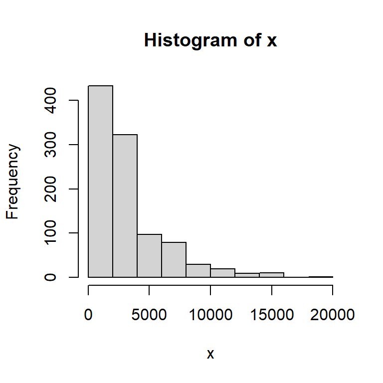

```r
> MeanSD(loans$Credit.amount, plot=TRUE)
```

```
$Mean
[1] 3271.258

$SD
[1] 2822.737
```